# Does the month matter in a marketing campaign?

Replication code for the bank marketing logistic regression exercise

24 November 2026

```r
library(tidyverse)
library(knitr)
```

# 1 Data

The data are the Bank Marketing dataset from the UCI Machine Learning Repository (Moro, Cortez & Rita, 2014): telephone marketing campaigns run by a Portuguese bank between May 2008 and November 2010. Put `bank-additional-full.csv` in the same folder as this `.Rmd`.

The file uses semicolons, not commas, to separate columns (a common European convention, because the comma is used as the decimal mark), so it is read with `read_delim(delim = ";")`.

```r
bank_raw <- read_delim("bank-additional-full.csv", delim = ";")
glimpse(bank_raw)
```

```
## Rows: 41,188
## Columns: 21
## $ age            <dbl> 56, 57, 37, 40, 56, 45, 59, 41, 24, 25, 41, 25, 29, 57,…
## $ job            <chr> "housemaid", "services", "services", "admin.", "service…
## $ marital        <chr> "married", "married", "married", "married", "married", …
## $ education      <chr> "basic.4y", "high.school", "high.school", "basic.6y", "…
## $ default        <chr> "no", "unknown", "no", "no", "no", "unknown", "no", "un…
## $ housing        <chr> "no", "no", "yes", "no", "no", "no", "no", "no", "yes",…
## $ loan           <chr> "no", "no", "no", "no", "yes", "no", "no", "no", "no", …
## $ contact        <chr> "telephone", "telephone", "telephone", "telephone", "te…
## $ month          <chr> "may", "may", "may", "may", "may", "may", "may", "may",…
## $ day_of_week    <chr> "mon", "mon", "mon", "mon", "mon", "mon", "mon", "mon",…
## $ duration       <dbl> 261, 149, 226, 151, 307, 198, 139, 217, 380, 50, 55, 22…
## $ campaign       <dbl> 1, 1, 1, 1, 1, 1, 1, 1, 1, 1, 1, 1, 1, 1, 1, 1, 1, 1, 1…
## $ pdays          <dbl> 999, 999, 999, 999, 999, 999, 999, 999, 999, 999, 999, …
## $ previous       <dbl> 0, 0, 0, 0, 0, 0, 0, 0, 0, 0, 0, 0, 0, 0, 0, 0, 0, 0, 0…
## $ poutcome       <chr> "nonexistent", "nonexistent", "nonexistent", "nonexiste…
## $ emp.var.rate   <dbl> 1.1, 1.1, 1.1, 1.1, 1.1, 1.1, 1.1, 1.1, 1.1, 1.1, 1.1, …
## $ cons.price.idx <dbl> 93.994, 93.994, 93.994, 93.994, 93.994, 93.994, 93.994,…
## $ cons.conf.idx  <dbl> -36.4, -36.4, -36.4, -36.4, -36.4, -36.4, -36.4, -36.4,…
## $ euribor3m      <dbl> 4.857, 4.857, 4.857, 4.857, 4.857, 4.857, 4.857, 4.857,…
## $ nr.employed    <dbl> 5191, 5191, 5191, 5191, 5191, 5191, 5191, 5191, 5191, 5…
## $ y              <chr> "no", "no", "no", "no", "no", "no", "no", "no", "no", "…
```

```r
count(bank_raw, month)
```

```
## # A tibble: 10 × 2
##    month     n
##    <chr> <int>
##  1 apr    2632
##  2 aug    6178
##  3 dec     182
##  4 jul    7174
##  5 jun    5318
##  6 mar     546
##  7 may   13769
##  8 nov    4101
##  9 oct     718
## 10 sep     570
```

```r
count(bank_raw, y)
```

```
## # A tibble: 2 × 2
##   y         n
##   <chr> <int>
## 1 no    36548
## 2 yes    4640
```

## 1.1 Data dictionary

```r
data_dictionary <- tribble(
  ~variable, ~description,
  "y",     "Whether the client subscribed to a term deposit (\"yes\" or \"no\")",
  "month", "Month of the last contact with the client (\"mar\" to \"dec\"; the year is not recorded)"
)
kable(data_dictionary, col.names = c("Variable", "Description"))
```

| Variable | Description |
| --- | --- |
| y | Whether the client subscribed to a term deposit (“yes” or “no”) |
| month | Month of the last contact with the client (“mar” to “dec”; the year is not recorded) |

```r
bank <- bank_raw |>
  transmute(
    subscribed = as.integer(y == "yes"),
    month = factor(month, levels = c("mar", "apr", "may", "jun", "jul",
                                     "aug", "sep", "oct", "nov", "dec"))
  )
glimpse(bank)
```

```
## Rows: 41,188
## Columns: 2
## $ subscribed <int> 0, 0, 0, 0, 0, 0, 0, 0, 0, 0, 0, 0, 0, 0, 0, 0, 0, 0, 0, 0,…
## $ month      <fct> may, may, may, may, may, may, may, may, may, may, may, may,…
```

# 2 Proportion subscribing and number contacted in each month

```r
# Overall proportion subscribing (reported in the write-up)
bank |> summarise(n = n(), subscribed = sum(subscribed), prop = mean(subscribed))
```

```
## # A tibble: 1 × 3
##       n subscribed  prop
##   <int>      <int> <dbl>
## 1 41188       4640  4640
```

```r
month_summary <- bank |>
  group_by(month) |>
  summarise(n = n(), prop = mean(subscribed)) |>
  mutate(share_of_contacts = n / sum(n))

kable(month_summary, digits = 3)
```

| month | n | prop | share_of_contacts |
| --- | --- | --- | --- |
| mar | 546 | 0.505 | 0.013 |
| apr | 2632 | 0.205 | 0.064 |
| may | 13769 | 0.064 | 0.334 |
| jun | 5318 | 0.105 | 0.129 |
| jul | 7174 | 0.090 | 0.174 |
| aug | 6178 | 0.106 | 0.150 |
| sep | 570 | 0.449 | 0.014 |
| oct | 718 | 0.439 | 0.017 |
| nov | 4101 | 0.101 | 0.100 |
| dec | 182 | 0.489 | 0.004 |

There are no contacts in January or February, so those months are missing.

```r
# Share of all contacts in the four months with the highest subscription rates
month_summary |>
  filter(month %in% c("mar", "sep", "oct", "dec")) |>
  summarise(n = sum(n), share_of_contacts = sum(share_of_contacts))
```

```
## # A tibble: 1 × 2
##       n share_of_contacts
##   <int>             <dbl>
## 1  2016            0.0489
```

# 3 Logistic regression

March is the first level of `month`, so it is the reference month. The model is

$$\log\left(\frac{p_i}{1-p_i}\right) =
\beta_0 + \beta_1\,\text{apr}_i + \beta_2\,\text{may}_i +
\beta_3\,\text{jun}_i + \beta_4\,\text{jul}_i + \beta_5\,\text{aug}_i +
\beta_6\,\text{sep}_i + \beta_7\,\text{oct}_i + \beta_8\,\text{nov}_i +
\beta_9\,\text{dec}_i$$

where $p_i$ is the probability that person $i$ subscribed, $\text{apr}_i$ to $\text{dec}_i$ are dummy variables equal to 1 if person $i$ was last contacted in that month and 0 otherwise, $\beta_0$ is the log odds of subscribing in March, and $\beta_1$ to $\beta_9$ are the differences in log odds between each month and March.

```r
m1 <- glm(subscribed ~ month, family = binomial, data = bank)
summary(m1)
```

```
##
## Call:
## glm(formula = subscribed ~ month, family = binomial, data = bank)
##
## Coefficients:
##             Estimate Std. Error z value Pr(>|z|)
## (Intercept)  0.02198    0.08560   0.257   0.7974
## monthapr    -1.37862    0.09829 -14.027   <2e-16 ***
## monthmay    -2.69893    0.09238 -29.217   <2e-16 ***
## monthjun    -2.16362    0.09657 -22.405   <2e-16 ***
## monthjul    -2.32994    0.09498 -24.531   <2e-16 ***
## monthaug    -2.15402    0.09505 -22.662   <2e-16 ***
## monthsep    -0.22619    0.12007  -1.884   0.0596 .
## monthoct    -0.26834    0.11394  -2.355   0.0185 *
## monthnov    -2.20332    0.10001 -22.031   <2e-16 ***
## monthdec    -0.06594    0.17122  -0.385   0.7001
## ---
## Signif. codes:  0 '***' 0.001 '**' 0.01 '*' 0.05 '.' 0.1 ' ' 1
##
## (Dispersion parameter for binomial family taken to be 1)
##
##     Null deviance: 28999  on 41187  degrees of freedom
## Residual deviance: 26823  on 41178  degrees of freedom
## AIC: 26843
##
## Number of Fisher Scoring iterations: 5
```

## 3.1 Does the proportion subscribing differ between months?

A likelihood ratio test compares the model with month to a model with only an intercept (the same probability in every month).

```r
m0 <- glm(subscribed ~ 1, family = binomial, data = bank)
anova(m0, m1, test = "Chisq")
```

```
## Analysis of Deviance Table
##
## Model 1: subscribed ~ 1
## Model 2: subscribed ~ month
##   Resid. Df Resid. Dev Df Deviance  Pr(>Chi)
## 1     41187      28999
## 2     41178      26824  9   2175.3 < 2.2e-16 ***
## ---
## Signif. codes:  0 '***' 0.001 '**' 0.01 '*' 0.05 '.' 0.1 ' ' 1
```

# 4 Predicted probabilities with 95% CIs

The confidence intervals are calculated on the log odds scale and then converted to probabilities, so they stay between 0 and 1.

```r
pred_df <- tibble(month = factor(levels(bank$month), levels = levels(bank$month)))

pred <- predict(m1, newdata = pred_df, type = "link", se.fit = TRUE)

pred_df <- pred_df |>
  mutate(
    log_odds = pred$fit,
    se       = pred$se.fit,
    p        = plogis(log_odds),
    lo       = plogis(log_odds - 1.96 * se),
    hi       = plogis(log_odds + 1.96 * se)
  )

kable(pred_df, digits = 3)
```

| month | log_odds | se | p | lo | hi |
| --- | --- | --- | --- | --- | --- |
| mar | 0.022 | 0.086 | 0.505 | 0.464 | 0.547 |
| apr | -1.357 | 0.048 | 0.205 | 0.190 | 0.221 |
| may | -2.677 | 0.035 | 0.064 | 0.060 | 0.069 |
| jun | -2.142 | 0.045 | 0.105 | 0.097 | 0.114 |
| jul | -2.308 | 0.041 | 0.090 | 0.084 | 0.097 |
| aug | -2.132 | 0.041 | 0.106 | 0.099 | 0.114 |
| sep | -0.204 | 0.084 | 0.449 | 0.409 | 0.490 |
| oct | -0.246 | 0.075 | 0.439 | 0.403 | 0.475 |
| nov | -2.181 | 0.052 | 0.101 | 0.093 | 0.111 |
| dec | -0.044 | 0.148 | 0.489 | 0.417 | 0.561 |

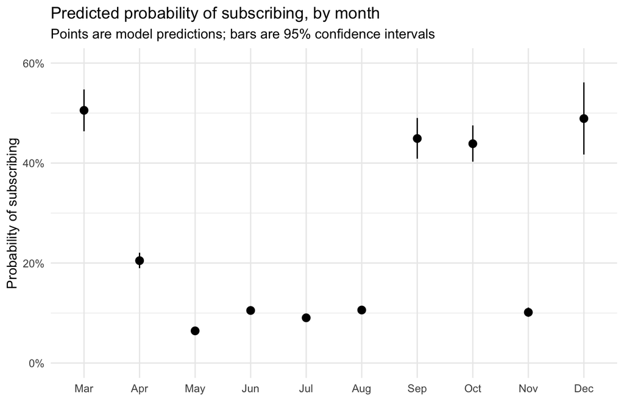

```r
p_pred <- ggplot(pred_df, aes(x = month, y = p)) +
  geom_pointrange(aes(ymin = lo, ymax = hi)) +
  scale_x_discrete(labels = str_to_title) +
  scale_y_continuous(labels = scales::percent, limits = c(0, 0.6)) +
  labs(x = NULL,
       y = "Probability of subscribing",
       title = "Predicted probability of subscribing, by month",
       subtitle = "Points are model predictions; bars are 95% confidence intervals") +
  theme_minimal()

p_pred
```

```r
ggsave("fig1_predicted_probabilities.png", p_pred, width = 7, height = 4, dpi = 300)
```

# 5 The odds of a subscription in September

```r
sep <- pred_df |> filter(month == "sep")
sep_odds <- sep$p / (1 - sep$p)
sep_odds
```

```
##         7
## 0.8152866
```

The odds are about 0.82: in September, roughly four people subscribed for every five who did not. This is not a probability; the probability of subscribing in September was about 45%.

## 5.1 By hand from the coefficients

```r
b <- coef(m1)
sep_log_odds_hand <- b["(Intercept)"] + b["monthsep"]           # 1. log odds
sep_odds_hand     <- exp(sep_log_odds_hand)                      # 2. odds
sep_p_hand        <- sep_odds_hand / (1 + sep_odds_hand)         # 3. probability

c(log_odds = sep_log_odds_hand, odds = sep_odds_hand, p = sep_p_hand)
```

```
## log_odds.(Intercept)     odds.(Intercept)        p.(Intercept)
##           -0.2042155            0.8152866            0.4491228
```

```r
sep   # matches the model predictions
```

```
## # A tibble: 1 × 6
##   month log_odds     se     p    lo    hi
##   <fct>    <dbl>  <dbl> <dbl> <dbl> <dbl>
## 1 sep     -0.204 0.0842 0.449 0.409 0.490
```

# 6 Why does the proportion subscribing vary over months?

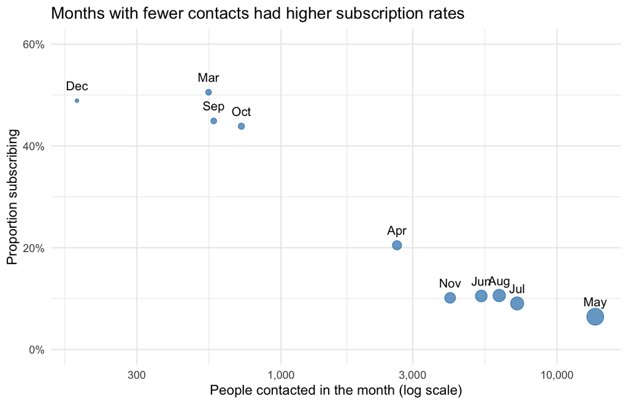

```r
p_why <- ggplot(month_summary, aes(x = n, y = prop)) +
  geom_point(aes(size = n), colour = "#2C7FB8", alpha = 0.7, show.legend = FALSE) +
  geom_text(aes(label = str_to_title(month)), vjust = -1.2, size = 3.5) +
  scale_x_log10(labels = scales::comma) +
  scale_y_continuous(labels = scales::percent, limits = c(0, 0.6)) +
  labs(x = "People contacted in the month (log scale)",
       y = "Proportion subscribing",
       title = "Months with fewer contacts had higher subscription rates") +
  theme_minimal()

p_why
```

```r
ggsave("fig2_contacts_vs_subscription.png", p_why, width = 7, height = 4.5, dpi = 300)
```

Months in which the bank contacted fewer people had higher subscription rates. This is an association: these data cannot show why. The year of each contact is not recorded, so months may also differ in, for example, economic conditions during 2008 to 2010.